# Homework Assignment 3

Clustering and Outlier Detection

Gus Lipkin - glipkin6737@floridapoly.edu

# DTMT in 2021

- HW3.
- Due day: Nov 4 - Nov 11 at 11:59pm (EST)
- The HW3 is modified by Jikhan Jeong and the original one comes from Prof. Rei.
- If you feel difficult, please go over
- Point 100 points
- Reference for data handling in R : https://r4ds.had.co.nz/index.html
- Reference for mudate function : https://r4ds.had.co.nz/transform.html#add-new-variables-with-mutate

Run the code below to lad the `tidyverse` package for data transformation and visualization, the `dbscan` package for clustering and outlier detection, and the `factoextra` package for quick visualizations of models (you are not required to use `factoextra` and can choose to use other methods for creating visualizations that explain your results when requested)

```r
getwd()
```

```
[1] "/Users/guslipkin/Documents/Fall2021/CAP 4770 ~ Data Mining/CAP 4770 Homework"
```

```r
library(tidyverse)
library(factoextra)
```

# Problem 1 : KMEAN (20 points)

- ref: 2021-10-19-dbscan-replication-html.html
- ref: https://r4ds.had.co.nz/index.html
- Read the dataset on corporate data for 22 public utilities in the United States.

```r
data <- read_csv("https://github.com/reisanar/datasets/raw/master/Utilities.csv")
summary(data)
```

```
   Company           Fixed_charge        RoR             Cost        Load_factor    Demand_growth        Sales          Nuclear       Fuel_Cost
 Length:22          Min.   :0.750   Min.   : 6.40   Min.   : 96.0   Min.   :49.80   Min.   :-2.200   Min.   : 3300   Min.   : 0.0   Min.   :0.309
 Class :character   1st Qu.:1.042   1st Qu.: 9.20   1st Qu.:148.5   1st Qu.:53.77   1st Qu.: 1.450   1st Qu.: 6458   1st Qu.: 0.0   1st Qu.:0.630
 Mode  :character   Median :1.110   Median :11.05   Median :170.5   Median :56.35   Median : 3.000   Median : 8024   Median : 0.0   Median :0.960
                    Mean   :1.114   Mean   :10.74   Mean   :168.2   Mean   :56.98   Mean   : 3.241   Mean   : 8914   Mean   :12.0   Mean   :1.103
                    3rd Qu.:1.190   3rd Qu.:12.35   3rd Qu.:195.8   3rd Qu.:60.30   3rd Qu.: 5.350   3rd Qu.:10128   3rd Qu.:24.6   3rd Qu.:1.516
                    Max.   :1.490   Max.   :15.40   Max.   :252.0   Max.   :67.60   Max.   : 9.200   Max.   :17441   Max.   :50.2   Max.   :2.116
```

```r
head(data)
```

| Company | Fixed_charge | RoR | Cost | Load_factor | Demand_growth | Sales | Nuclear | Fuel_Cost |
| --- | --- | --- | --- | --- | --- | --- | --- | --- |
| Arizona | 1.06 | 9.2 | 151 | 54.4 | 1.6 | 9077 | 0.0 | 0.628 |
| Boston | 0.89 | 10.3 | 202 | 57.9 | 2.2 | 5088 | 25.3 | 1.555 |
| Central | 1.43 | 15.4 | 113 | 53.0 | 3.4 | 9212 | 0.0 | 1.058 |
| Commonwealth | 1.02 | 11.2 | 168 | 56.0 | 0.3 | 6423 | 34.3 | 0.700 |
| NY | 1.49 | 8.8 | 192 | 51.2 | 1.0 | 3300 | 15.6 | 2.044 |
| Florida | 1.32 | 13.5 | 111 | 60.0 | -2.2 | 11127 | 22.5 | 1.241 |

- sample size is 22.

```r
dim(data)
```

```
[1] 22  9
```

### Meaning of key variables

- RoR : Percent rate of return on capital
- Sales : Total Power Sales (KWH use per year)

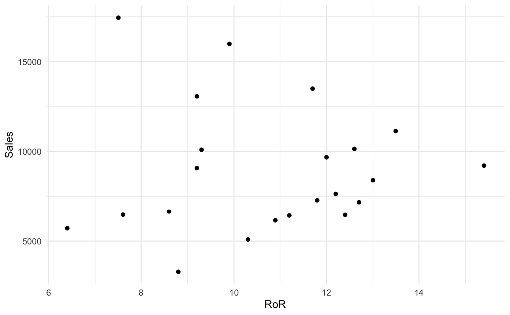

```r
ggplot(data= data) +
  geom_point(aes(x = RoR, y = Sales)) +
  theme_minimal()
```

- change data as data_1 and add new variables by using log(Sales)

```r
data_1 <- data %>%
  mutate(log_sales = log(Sales))
head(data_1)
```

| Company | Fixed_charge | RoR | Cost | Load_factor | Demand_growth | Sales | Nuclear | Fuel_Cost | log_sales |
| --- | --- | --- | --- | --- | --- | --- | --- | --- | --- |
| Arizona | 1.06 | 9.2 | 151 | 54.4 | 1.6 | 9077 | 0.0 | 0.628 | 9.113499 |
| Boston | 0.89 | 10.3 | 202 | 57.9 | 2.2 | 5088 | 25.3 | 1.555 | 8.534640 |
| Central | 1.43 | 15.4 | 113 | 53.0 | 3.4 | 9212 | 0.0 | 1.058 | 9.128262 |
| Commonwealth | 1.02 | 11.2 | 168 | 56.0 | 0.3 | 6423 | 34.3 | 0.700 | 8.767641 |
| NY | 1.49 | 8.8 | 192 | 51.2 | 1.0 | 3300 | 15.6 | 2.044 | 8.101678 |
| Florida | 1.32 | 13.5 | 111 | 60.0 | -2.2 | 11127 | 22.5 | 1.241 | 9.317130 |

- check the graph using data_1

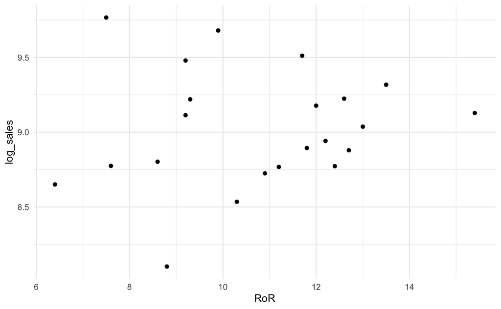

```r
ggplot(data= data_1) +
  geom_point(aes(x = RoR, y = log_sales))+
  theme_minimal()
```

```r
data_2 <- data_1[, c(3, 10)]

head(data_2)
```

| RoR | log_sales |
| --- | --- |
| 9.2 | 9.113499 |
| 10.3 | 8.534640 |
| 15.4 | 9.128262 |
| 11.2 | 8.767641 |
| 8.8 | 8.101678 |
| 13.5 | 9.317130 |

### (To-Do, 10 points) Q1-1

- Apply k-means with the group

```r
data_2_kmeans <- kmeans(data_2, centers = 3)
summary(data_2_kmeans)
```

```
             Length Class  Mode
cluster      22     -none- numeric
centers       6     -none- numeric
totss         1     -none- numeric
withinss      3     -none- numeric
tot.withinss  1     -none- numeric
betweenss     1     -none- numeric
size          3     -none- numeric
iter          1     -none- numeric
ifault        1     -none- numeric
```

```r
data_2$cluster <- as.factor(data_2_kmeans$cluster)
```

### (To-Do, 10 points) Q1-2

- Please provide cluster plot by using **fviz_cluster**
- How do you think about the result?

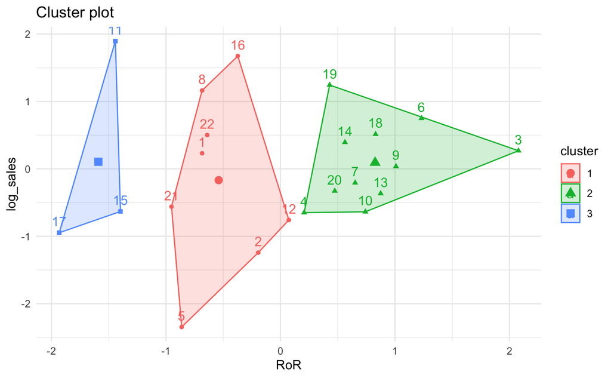

```r
fviz_cluster(data_2_kmeans, data = data_2, choose.vars = c("RoR", "log_sales")) +
  theme_minimal()
```

> Since the problem didn’t say how many centers to use, I decided to settle on three. There’s a general grouping by left, center, and right. I tried more clusters and the grouping continued across the horizontal axis, leading me to believe that the largest deciding factor in the `log_sales` variable is the RoR.

# Problem 2 : Dedensity-based clustering algorithm (DBSCAN); (20 points)

- using the same dataset with Q1.
- dataset : data_2
- ref: CW_anomalies-replication-2021-10-21.html

```r
dim(data_2)
```

```
[1] 22  3
```

```r
head(data_2)
```

| RoR | log_sales | cluster |
| --- | --- | --- |
| 9.2 | 9.113499 | 1 |
| 10.3 | 8.534640 | 1 |
| 15.4 | 9.128262 | 2 |
| 11.2 | 8.767641 | 2 |
| 8.8 | 8.101678 | 1 |
| 13.5 | 9.317130 | 2 |

### (To-Do, 15 points) Q2-1 : Apply dbscan

- please run dbscan by using dbscan package
- there are two hyper-parameters (1) eps (2) minPts
- For now, please set (1) eps = 0.5, (2) minPts =3
- (5 points, show the result)Please show your results
- (5 points, Need to answer) What is the number of clusters?
- (5 points, Need to answer) What is the number of noisy points?
- dataset: data_2

```r
library(dbscan)
```

```r
# in the result, 0 cluster means noisy point
data_2_dbscan <- dbscan(x = data_2[,1:2], eps = .5, minPts = 3)
data_2_dbscan
```

```
DBSCAN clustering for 22 objects.
Parameters: eps = 0.5, minPts = 3
The clustering contains 2 cluster(s) and 11 noise points.

 0  1  2
11  3  8

Available fields: cluster, eps, minPts
```

> There are `two clusters` with `11` noisy points. There are 3 points in group 1 and 8 points in group 2.

### (To-Do, 5 points) Q2-2 : show the graph of dbscan

- (5 points, Need to show the graph) Please show the graph of the result from the above dbscan using fviz_cluster

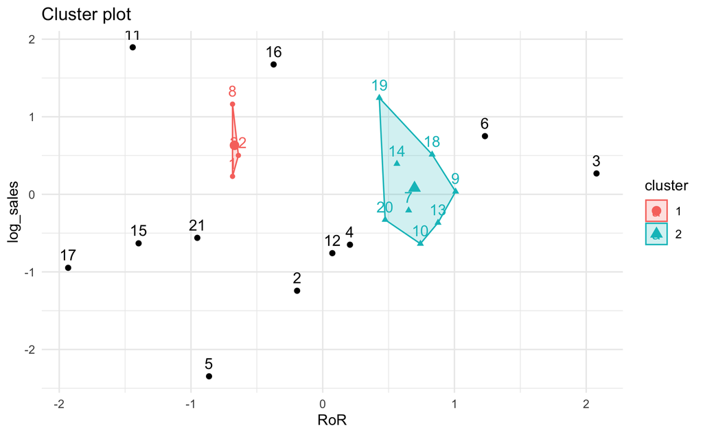

```r
fviz_cluster(object = data_2_dbscan, data = data_2, choose.vars = c("RoR", "log_sales")) +
  theme_minimal()
```

# Problem 3 : Paper Review (no code for this problem); (20 points)

- (To DO) 1. Please choose one paper related to your project

### (To-Do, 5 point) Q3-1

- (To DO, 5 points) 2. Please share the citation information (5 point) using https://scholar.google.com/

> Lipkin, G., Pierstorff, A., Skoglund, H. (2020). Final Report for Intro to Data Science. Florida Polytechnic University. https://github.com/guslipkin/disney_ds/blob/master/project/report_and_code.pdf

### (To-Do, 15 point) Q3-2

- (To Do, 15 points) 3. Please share your story, why do you choose this paper and what makes this paper looks fun in 200 words.(5 points)

> I chose this paper because we were considering doing a continuation of it. In Intro to Data Science, we used basic statistical analysis to find the best times to go to Disney World based on factors such as, time of year, time of day, day of the week, and the weather (rainfall, temperature, humidity, etc) to see if we could pinpoint a time when ride wait times would be shortest. We wanted to revisit that project because we’ve learned so much more about data analysis since then, including principal component analysis, association rule mining, and from other classes, time series analysis. We’re hoping that with these new tools we can improve on what we’ve already accomplished. We’d like to use PCA to find groups of factors that lead to longer wait times and then also association rule mining to find which rides are likely to have shorter or longer wait times at the same time to learn if there are certain properties that those rides share that make them popular to be busy or not at the same times. I’m also hoping that throwing in a bit of time series analysis will help us get rid of seasonal trends so that we can just work with raw data, although I know that that’s not always how it works.

# Problem 4 : Outlier Detection using clustering (20 points)

- ref: CW_anomalies-replication-2021-10-21.html
- dataset: data_2 (the same data set with the above)

### (To-Do, 10 point) Q4-1

- (5 point) please run kmeans with **data_2** dataset with **the cluster number 3 (k=3)** and
- (5 point) please provide cluster means for 3 clusters.

```r
kmeans_result <- kmeans(x = data_2, centers = 3)
kmeans_result
```

```
K-means clustering with 3 clusters of sizes 3, 11, 8

Cluster means:
        RoR log_sales cluster
1  7.166667  9.063959       3
2 12.590909  9.058984       2
3  9.525000  8.956927       1

Clustering vector:
 [1] 3 3 2 2 3 2 2 3 2 2 1 3 2 2 1 3 1 2 2 2 3 3

Within cluster sum of squares by cluster:
[1]  1.634861 13.346980  6.151102
 (between_SS / total_SS =  82.2 %)

Available components:

[1] "cluster"      "centers"      "totss"        "withinss"     "tot.withinss" "betweenss"    "size"         "iter"         "ifault"
```

```r
data_2 %>%
  mutate(cluster = kmeans_result$cluster) %>%
  group_by(cluster) %>%
  summarize(meanRoR = mean(RoR), meanLogSales = mean(log_sales))
```

| cluster | meanRoR | meanLogSales |
| --- | --- | --- |
| 1 | 7.166667 | 9.063959 |
| 2 | 12.590909 | 9.058984 |
| 3 | 9.525000 | 8.956927 |

### (To-Do, 10 point) Q4-2

- please go over the code in CW_anomalies-replication-2021-10-21.html and
- (10 points) please where are the top 5 outliers?

```r
# calculate distances between objects and cluster centers
centers <- kmeans_result$centers[kmeans_result$cluster, ]
# compute Euclidean distance
km_distances <- sqrt(rowSums((iris_2 - centers) ^ 2))
# pick top 5 largest distances
km_outliers <- order(km_distances, decreasing = T)[1:5]
# which ones are outliers?
print(km_outliers)
```

[output not shown]

# Problem 5 : Outliner Detection using LOF (Local Outlier Factor) (20 points)

- Ref: CW_anomalies-replication-2021-10-21.html
- dataset : data_2

```r
data_2
```

| RoR | log_sales | cluster |
| --- | --- | --- |
| 9.2 | 9.113499 | 1 |
| 10.3 | 8.534640 | 1 |
| 15.4 | 9.128262 | 2 |
| 11.2 | 8.767641 | 2 |
| 8.8 | 8.101678 | 1 |
| 13.5 | 9.317130 | 2 |
| 12.2 | 8.941415 | 2 |
| 9.2 | 9.478993 | 1 |
| 13.0 | 9.036701 | 2 |
| 12.4 | 8.772610 | 2 |

[output cut: 12 more lines]

```r
library(dbscan)
```

### (To-Do, 10 point) Q5-1

- Use the lof() to calculate the LOF score for each data point when k is 3
- when lof score is bigger than 1 means outliers

```r
lof_scores <-lof(data_2[,1:2], k = 3)
lof_scores
```

```
 [1] 0.9434368 1.1996437 3.8115664 1.2606492 1.2897279 1.5239969 1.0590176 1.0015207 1.0355022 0.8325897 1.2651646 1.4338624 1.0726247 1.1063373
[15] 1.2317648 1.0314858 1.2993200 0.8787498 1.1543100 0.9774266 1.0758424 0.9855383
```

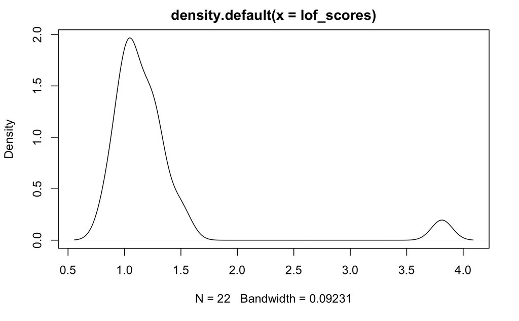

```r
plot(density(lof_scores))
```

### (To-Do, 10 point) Q5-2

- Please find out the index for the top 5 outliers and show its table

```r
outliers <- order(lof_scores, decreasing = T)[1:5]
outliers
```

```
[1]  3  6 12 17  5
```

```r
data_2[outliers,]
```

| RoR | log_sales | cluster |
| --- | --- | --- |
| 15.4 | 9.128262 | 2 |
| 13.5 | 9.317130 | 2 |
| 10.9 | 8.724858 | 1 |
| 6.4 | 8.650675 | 3 |
| 8.8 | 8.101678 | 1 |